# Oysters_DADA2

Winston Liu

February 19, 2020

## Data storage

Downloaded from sequencing core into /sharedspace/oysters/data

#Libraries

```r
library(readr)
library(fs)
library(R.utils)
library(tidyverse)
```

```r
library(stringr)
library(phyloseq)
library(ggplot2)
library(dada2)
library(magrittr)
```

# INPUTS

Folder names:

```r
baseFolder <- "/sharedspace/oysters/data"

outputFiltered <- "/sharedspace/oysters/scratch/filtered"
output.dir <- "/sharedspace/oysters/output"
ps.file <- file.path(output.dir,"ps_oysters.rds")
track.file <- file.path(output.dir,"track_oysters.rds")
```

Read in the files:

```r
R1.fileName <- list.files(baseFolder, pattern = "R1_001.fastq.gz")
```

# SAMPLE TABLE

```r
R2.fileName <- str_replace(R1.fileName,"R1","R2")
sampleInfo <- data.frame(R1.fileName, R2.fileName)
sampleInfo %<>%
  separate(R1.fileName, into = "sampleName", sep = "_", remove=FALSE)
```

# View quality profiles

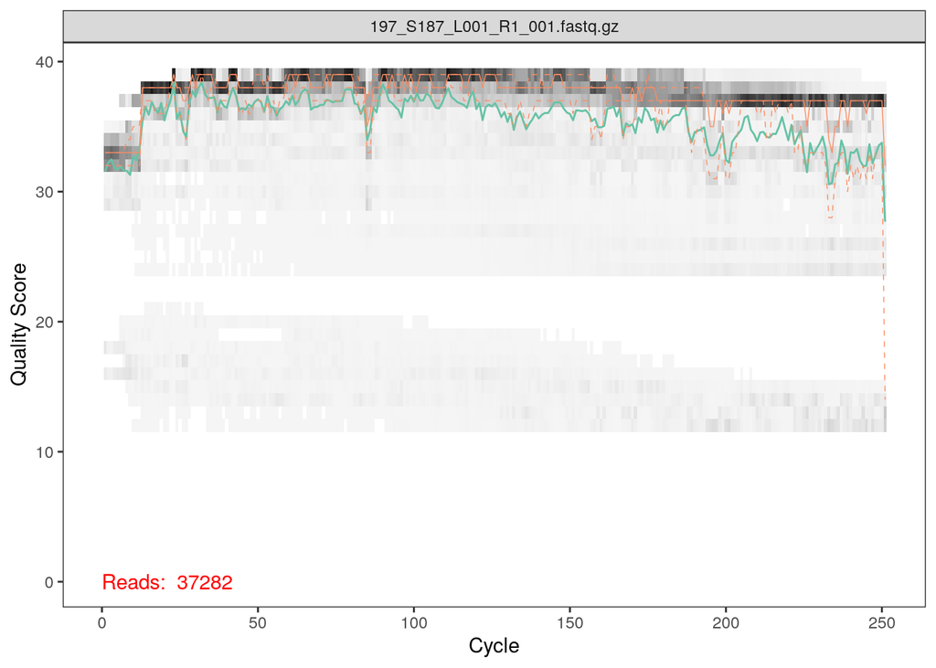

```r
i<-10
plotQualityProfile(file.path(baseFolder, sampleInfo$R1.fileName[i]))
```

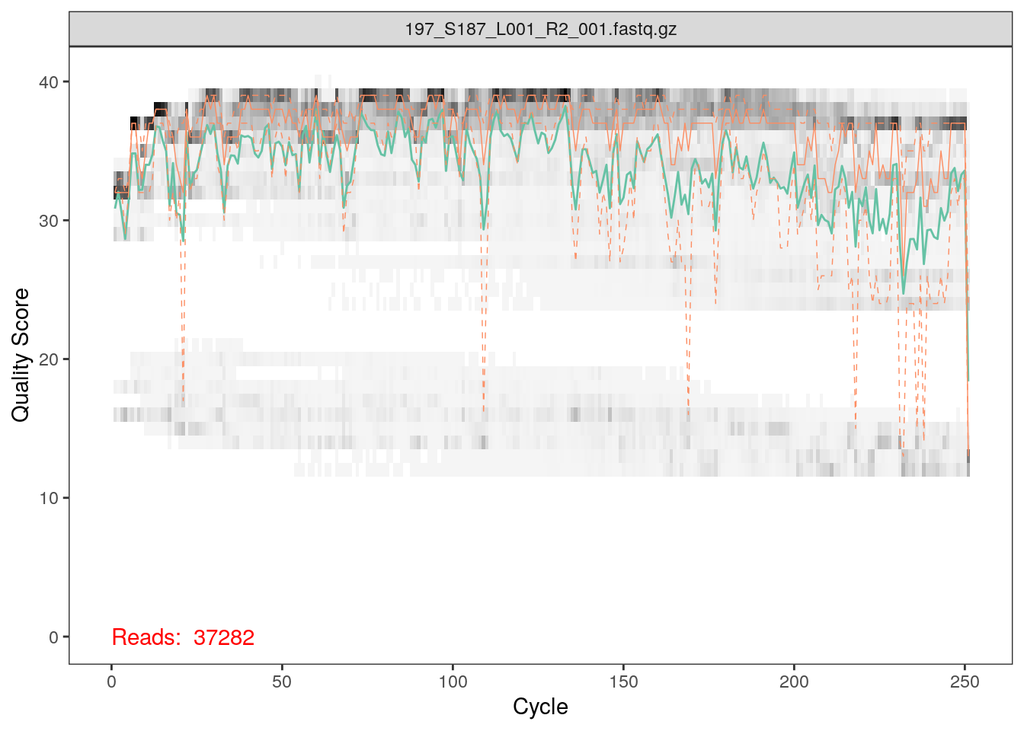

```r
plotQualityProfile(file.path(baseFolder, sampleInfo$R2.fileName[i]))
```

# Perform filtering and trimming

### Generate filenames for the filtered fastq.gz files.

You need to use the names of the raw (demultiplexed) FASTQ files to generate a vector of names for the filtered FASTQs. You need separate vectors for the forward and reverse reads. It is a very good idea to put all the filtered FASTQs in their own directory.

```r
filtFs <- file.path(outputFiltered , paste0(sampleInfo$sampleName, "_F_filt.fastq.gz"))
filtRs <- file.path(outputFiltered , paste0(sampleInfo$sampleName, "_R_filt.fastq.gz"))
fnFs <- file.path(baseFolder,as.character(sampleInfo$R1.fileName))
fnRs <- file.path(baseFolder,as.character(sampleInfo$R2.fileName))
```

### Filter the forward and reverse reads

Now let’s do the filtering using the parameters we chose based on the quality plots

```r
filt.out <- filterAndTrim(fwd = fnFs, filt = filtFs, rev = fnRs, filt.rev = filtRs, trimLeft=10, truncLen=c(245,225),
              maxN=0, maxEE=c(2,2), truncQ=2, rm.phix=TRUE,
              compress=TRUE, multithread=FALSE) # On Windows set multithread=FALSE
```

```
## Creating output directory: /sharedspace/oysters/scratch/filtered
```

```r
filt.out
```

```
##                                   reads.in reads.out
## 188_S178_L001_R1_001.fastq.gz        66248     57778
## 189_S179_L001_R1_001.fastq.gz        77157     66795
## 190_S180_L001_R1_001.fastq.gz        65599     56711
## 191_S181_L001_R1_001.fastq.gz        56547     40427
## 192_S182_L001_R1_001.fastq.gz        34606     29873
## 193_S183_L001_R1_001.fastq.gz         7654      6435
## 194_S184_L001_R1_001.fastq.gz        28480     25076
## 195_S185_L001_R1_001.fastq.gz        16648     14653
## 196_S186_L001_R1_001.fastq.gz        12718     10902
## 197_S187_L001_R1_001.fastq.gz        37282     32429
## 198_S188_L001_R1_001.fastq.gz         5897      5334
## 199_S189_L001_R1_001.fastq.gz         9553      8246
## 200_S190_L001_R1_001.fastq.gz         7790      6803
## 201_S191_L001_R1_001.fastq.gz        49886     42652
## 202_S192_L001_R1_001.fastq.gz        47908     42936
## 203_S193_L001_R1_001.fastq.gz        13702     12393
## 204_S194_L001_R1_001.fastq.gz        28559     23877
## 205_S195_L001_R1_001.fastq.gz         4801      4369
## 206_S196_L001_R1_001.fastq.gz        58210     51469
## 207_S197_L001_R1_001.fastq.gz        71973     64866
## 208_S198_L001_R1_001.fastq.gz        30982     26677
## 209_S199_L001_R1_001.fastq.gz        16895     15169
## 210_S200_L001_R1_001.fastq.gz         8109      7184
## 211_S201_L001_R1_001.fastq.gz        13722     11877
## 212_S202_L001_R1_001.fastq.gz         8090      7262
## 213_S203_L001_R1_001.fastq.gz        19639     17174
## 214_S204_L001_R1_001.fastq.gz         7854      6933
## 215_S205_L001_R1_001.fastq.gz        10231      8760
## 216_S206_L001_R1_001.fastq.gz        21268     18210
## 217_S207_L001_R1_001.fastq.gz        25317     22101
## 218_S208_L001_R1_001.fastq.gz        16418     13869
## 219_S209_L001_R1_001.fastq.gz        14622     12572
## 220_S210_L001_R1_001.fastq.gz        26164     22856
## 221_S211_L001_R1_001.fastq.gz        28879     25002
## 222_S212_L001_R1_001.fastq.gz        12463     10308
## 223_S213_L001_R1_001.fastq.gz        72125     63917
## 224_S214_L001_R1_001.fastq.gz        47465     41879
## 225_S215_L001_R1_001.fastq.gz        47980     40779
## 226_S216_L001_R1_001.fastq.gz         7291      6114
## 227_S217_L001_R1_001.fastq.gz         3168      2650
## 228_S218_L001_R1_001.fastq.gz         4516      3988
## 229_S219_L001_R1_001.fastq.gz         1659      1319
## PG1_S221_L001_R1_001.fastq.gz         7184      5207
## PG2_S222_L001_R1_001.fastq.gz         4272      3332
## PG3_S223_L001_R1_001.fastq.gz          924       682
## PGblank_S220_L001_R1_001.fastq.gz     1274      1100
```

### Tweak Filtered FASTQ list

```r
filtFs <- filtFs[file_exists(filtFs)]
filtRs <- filtRs[file_exists(filtRs)]
sample.names <- filtFs  %>%
  basename %>%
  str_replace("_F_filt.fastq.gz","")
```

## Learn the Error Rates

With that bit of cleanup done, we are ready to build an error model from the filtered FASTQs. We do this seperately for the R1 and R2 FASTQs, since they have different patterns of errors, as we have seen.

```r
errF <- learnErrors(filtFs, multithread=TRUE)
```

```
## 105056750 total bases in 447050 reads from 15 samples will be used for learning the error rates.
```

```r
errR <- learnErrors(filtRs, multithread=TRUE)
```

```
## 103913800 total bases in 483320 reads from 17 samples will be used for learning the error rates.
```

It is always worthwhile, as a sanity check if nothing else, to visualize the estimated error rates:

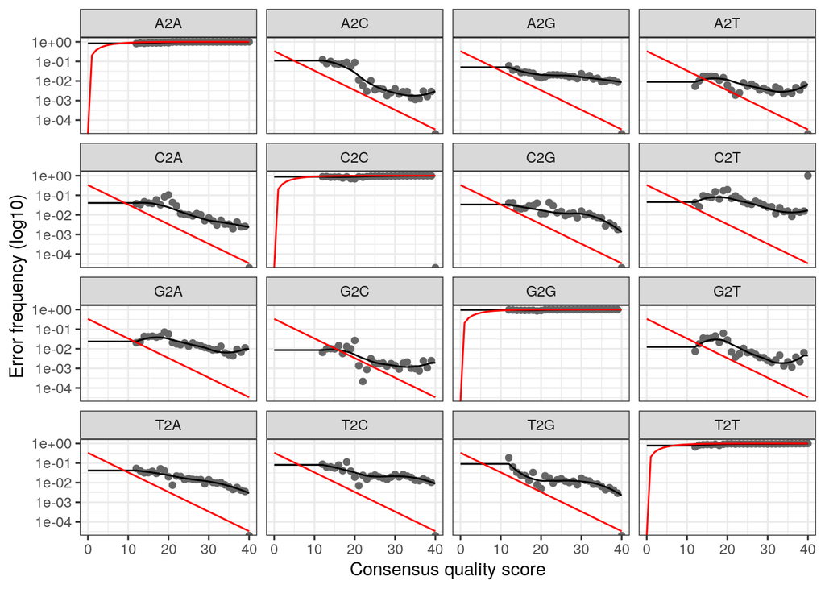

```r
plotErrors(errF, nominalQ=TRUE)
```

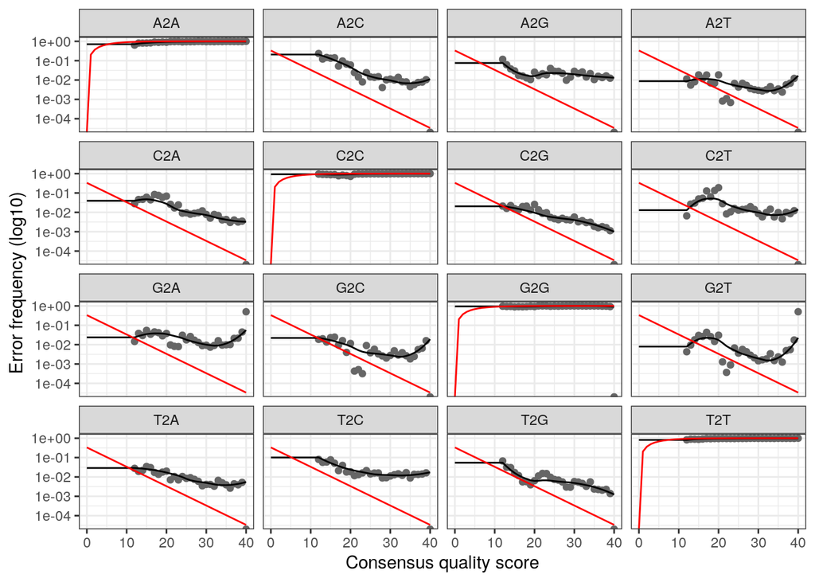

```r
plotErrors(errR, nominalQ=TRUE)
```

The error rates for each possible transition (eg. A->C, A->G, …) are shown. Points are the observed error rates for each consensus quality score. The black line shows the estimated error rates after convergence. The red line shows the error rates expected under the nominal definition of the Q-value. Here the black line (the estimated rates) fits the observed rates well, and the error rates drop with increased quality as expected.

Since we are using a small subset of the data, the learned error rates might look funny. This is OK for now, since we are just doing a pilot analysis.

## Dereplication

Dereplication combines all identical sequencing reads into “unique sequences” with a corresponding “abundance” tally: the number of reads with that unique sequence. Dereplication substantially reduces computation time for the inference step, since we only need to do inference for unique sequences.

```r
derepFs <- derepFastq(filtFs, verbose=TRUE)
```

```
## Dereplicating sequence entries in Fastq file: /sharedspace/oysters/scratch/filtered/188_F_filt.fastq.gz
```

```
## Encountered 28632 unique sequences from 57778 total sequences read.
```

```
## Dereplicating sequence entries in Fastq file: /sharedspace/oysters/scratch/filtered/189_F_filt.fastq.gz
```

```
## Encountered 35365 unique sequences from 66795 total sequences read.
```

```
## Dereplicating sequence entries in Fastq file: /sharedspace/oysters/scratch/filtered/190_F_filt.fastq.gz
```

```
## Encountered 30522 unique sequences from 56711 total sequences read.
```

```
## Dereplicating sequence entries in Fastq file: /sharedspace/oysters/scratch/filtered/191_F_filt.fastq.gz
```

```
## Encountered 21301 unique sequences from 40427 total sequences read.
```

```
## Dereplicating sequence entries in Fastq file: /sharedspace/oysters/scratch/filtered/192_F_filt.fastq.gz
```

```
## Encountered 16078 unique sequences from 29873 total sequences read.
```

```
## Dereplicating sequence entries in Fastq file: /sharedspace/oysters/scratch/filtered/193_F_filt.fastq.gz
```

```
## Encountered 3683 unique sequences from 6435 total sequences read.
```

```
## Dereplicating sequence entries in Fastq file: /sharedspace/oysters/scratch/filtered/194_F_filt.fastq.gz
```

```
## Encountered 15008 unique sequences from 25076 total sequences read.
```

```
## Dereplicating sequence entries in Fastq file: /sharedspace/oysters/scratch/filtered/195_F_filt.fastq.gz
```

```
## Encountered 9144 unique sequences from 14653 total sequences read.
```

```
## Dereplicating sequence entries in Fastq file: /sharedspace/oysters/scratch/filtered/196_F_filt.fastq.gz
```

```
## Encountered 6542 unique sequences from 10902 total sequences read.
```

```
## Dereplicating sequence entries in Fastq file: /sharedspace/oysters/scratch/filtered/197_F_filt.fastq.gz
```

```
## Encountered 18934 unique sequences from 32429 total sequences read.
```

```
## Dereplicating sequence entries in Fastq file: /sharedspace/oysters/scratch/filtered/198_F_filt.fastq.gz
```

```
## Encountered 2729 unique sequences from 5334 total sequences read.
```

```
## Dereplicating sequence entries in Fastq file: /sharedspace/oysters/scratch/filtered/199_F_filt.fastq.gz
```

```
## Encountered 3809 unique sequences from 8246 total sequences read.
```

```
## Dereplicating sequence entries in Fastq file: /sharedspace/oysters/scratch/filtered/200_F_filt.fastq.gz
```

```
## Encountered 3175 unique sequences from 6803 total sequences read.
```

```
## Dereplicating sequence entries in Fastq file: /sharedspace/oysters/scratch/filtered/201_F_filt.fastq.gz
```

```
## Encountered 14648 unique sequences from 42652 total sequences read.
```

```
## Dereplicating sequence entries in Fastq file: /sharedspace/oysters/scratch/filtered/202_F_filt.fastq.gz
```

```
## Encountered 17276 unique sequences from 42936 total sequences read.
```

```
## Dereplicating sequence entries in Fastq file: /sharedspace/oysters/scratch/filtered/203_F_filt.fastq.gz
```

```
## Encountered 6756 unique sequences from 12393 total sequences read.
```

```
## Dereplicating sequence entries in Fastq file: /sharedspace/oysters/scratch/filtered/204_F_filt.fastq.gz
```

```
## Encountered 8835 unique sequences from 23877 total sequences read.
```

```
## Dereplicating sequence entries in Fastq file: /sharedspace/oysters/scratch/filtered/205_F_filt.fastq.gz
```

```
## Encountered 2004 unique sequences from 4369 total sequences read.
```

```
## Dereplicating sequence entries in Fastq file: /sharedspace/oysters/scratch/filtered/206_F_filt.fastq.gz
```

```
## Encountered 20390 unique sequences from 51469 total sequences read.
```

```
## Dereplicating sequence entries in Fastq file: /sharedspace/oysters/scratch/filtered/207_F_filt.fastq.gz
```

```
## Encountered 23279 unique sequences from 64866 total sequences read.
```

```
## Dereplicating sequence entries in Fastq file: /sharedspace/oysters/scratch/filtered/208_F_filt.fastq.gz
```

```
## Encountered 13479 unique sequences from 26677 total sequences read.
```

```
## Dereplicating sequence entries in Fastq file: /sharedspace/oysters/scratch/filtered/209_F_filt.fastq.gz
```

```
## Encountered 8012 unique sequences from 15169 total sequences read.
```

```
## Dereplicating sequence entries in Fastq file: /sharedspace/oysters/scratch/filtered/210_F_filt.fastq.gz
```

```
## Encountered 4036 unique sequences from 7184 total sequences read.
```

```
## Dereplicating sequence entries in Fastq file: /sharedspace/oysters/scratch/filtered/211_F_filt.fastq.gz
```

```
## Encountered 6097 unique sequences from 11877 total sequences read.
```

```
## Dereplicating sequence entries in Fastq file: /sharedspace/oysters/scratch/filtered/212_F_filt.fastq.gz
```

```
## Encountered 3932 unique sequences from 7262 total sequences read.
```

```
## Dereplicating sequence entries in Fastq file: /sharedspace/oysters/scratch/filtered/213_F_filt.fastq.gz
```

```
## Encountered 8928 unique sequences from 17174 total sequences read.
```

```
## Dereplicating sequence entries in Fastq file: /sharedspace/oysters/scratch/filtered/214_F_filt.fastq.gz
```

```
## Encountered 3706 unique sequences from 6933 total sequences read.
```

```
## Dereplicating sequence entries in Fastq file: /sharedspace/oysters/scratch/filtered/215_F_filt.fastq.gz
```

```
## Encountered 4840 unique sequences from 8760 total sequences read.
```

```
## Dereplicating sequence entries in Fastq file: /sharedspace/oysters/scratch/filtered/216_F_filt.fastq.gz
```

```
## Encountered 9687 unique sequences from 18210 total sequences read.
```

```
## Dereplicating sequence entries in Fastq file: /sharedspace/oysters/scratch/filtered/217_F_filt.fastq.gz
```

```
## Encountered 11278 unique sequences from 22101 total sequences read.
```

```
## Dereplicating sequence entries in Fastq file: /sharedspace/oysters/scratch/filtered/218_F_filt.fastq.gz
```

```
## Encountered 8554 unique sequences from 13869 total sequences read.
```

```
## Dereplicating sequence entries in Fastq file: /sharedspace/oysters/scratch/filtered/219_F_filt.fastq.gz
```

```
## Encountered 8385 unique sequences from 12572 total sequences read.
```

```
## Dereplicating sequence entries in Fastq file: /sharedspace/oysters/scratch/filtered/220_F_filt.fastq.gz
```

```
## Encountered 14024 unique sequences from 22856 total sequences read.
```

```
## Dereplicating sequence entries in Fastq file: /sharedspace/oysters/scratch/filtered/221_F_filt.fastq.gz
```

```
## Encountered 14419 unique sequences from 25002 total sequences read.
```

```
## Dereplicating sequence entries in Fastq file: /sharedspace/oysters/scratch/filtered/222_F_filt.fastq.gz
```

```
## Encountered 6071 unique sequences from 10308 total sequences read.
```

```
## Dereplicating sequence entries in Fastq file: /sharedspace/oysters/scratch/filtered/223_F_filt.fastq.gz
```

```
## Encountered 25605 unique sequences from 63917 total sequences read.
```

```
## Dereplicating sequence entries in Fastq file: /sharedspace/oysters/scratch/filtered/224_F_filt.fastq.gz
```

```
## Encountered 22662 unique sequences from 41879 total sequences read.
```

```
## Dereplicating sequence entries in Fastq file: /sharedspace/oysters/scratch/filtered/225_F_filt.fastq.gz
```

```
## Encountered 15789 unique sequences from 40779 total sequences read.
```

```
## Dereplicating sequence entries in Fastq file: /sharedspace/oysters/scratch/filtered/226_F_filt.fastq.gz
```

```
## Encountered 3964 unique sequences from 6114 total sequences read.
```

```
## Dereplicating sequence entries in Fastq file: /sharedspace/oysters/scratch/filtered/227_F_filt.fastq.gz
```

```
## Encountered 1673 unique sequences from 2650 total sequences read.
```

```
## Dereplicating sequence entries in Fastq file: /sharedspace/oysters/scratch/filtered/228_F_filt.fastq.gz
```

```
## Encountered 1449 unique sequences from 3988 total sequences read.
```

```
## Dereplicating sequence entries in Fastq file: /sharedspace/oysters/scratch/filtered/229_F_filt.fastq.gz
```

```
## Encountered 593 unique sequences from 1319 total sequences read.
```

```
## Dereplicating sequence entries in Fastq file: /sharedspace/oysters/scratch/filtered/PG1_F_filt.fastq.gz
```

```
## Encountered 2989 unique sequences from 5207 total sequences read.
```

```
## Dereplicating sequence entries in Fastq file: /sharedspace/oysters/scratch/filtered/PG2_F_filt.fastq.gz
```

```
## Encountered 1807 unique sequences from 3332 total sequences read.
```

```
## Dereplicating sequence entries in Fastq file: /sharedspace/oysters/scratch/filtered/PG3_F_filt.fastq.gz
```

```
## Encountered 402 unique sequences from 682 total sequences read.
```

```
## Dereplicating sequence entries in Fastq file: /sharedspace/oysters/scratch/filtered/PGblank_F_filt.fastq.gz
```

```
## Encountered 309 unique sequences from 1100 total sequences read.
```

```r
derepRs <- derepFastq(filtRs, verbose=TRUE)
```

```
## Dereplicating sequence entries in Fastq file: /sharedspace/oysters/scratch/filtered/188_R_filt.fastq.gz
```

```
## Encountered 36575 unique sequences from 57778 total sequences read.
```

```
## Dereplicating sequence entries in Fastq file: /sharedspace/oysters/scratch/filtered/189_R_filt.fastq.gz
```

```
## Encountered 42180 unique sequences from 66795 total sequences read.
```

```
## Dereplicating sequence entries in Fastq file: /sharedspace/oysters/scratch/filtered/190_R_filt.fastq.gz
```

```
## Encountered 36121 unique sequences from 56711 total sequences read.
```

```
## Dereplicating sequence entries in Fastq file: /sharedspace/oysters/scratch/filtered/191_R_filt.fastq.gz
```

```
## Encountered 31090 unique sequences from 40427 total sequences read.
```

```
## Dereplicating sequence entries in Fastq file: /sharedspace/oysters/scratch/filtered/192_R_filt.fastq.gz
```

```
## Encountered 20093 unique sequences from 29873 total sequences read.
```

```
## Dereplicating sequence entries in Fastq file: /sharedspace/oysters/scratch/filtered/193_R_filt.fastq.gz
```

```
## Encountered 4704 unique sequences from 6435 total sequences read.
```

```
## Dereplicating sequence entries in Fastq file: /sharedspace/oysters/scratch/filtered/194_R_filt.fastq.gz
```

```
## Encountered 16967 unique sequences from 25076 total sequences read.
```

```
## Dereplicating sequence entries in Fastq file: /sharedspace/oysters/scratch/filtered/195_R_filt.fastq.gz
```

```
## Encountered 10594 unique sequences from 14653 total sequences read.
```

```
## Dereplicating sequence entries in Fastq file: /sharedspace/oysters/scratch/filtered/196_R_filt.fastq.gz
```

```
## Encountered 7605 unique sequences from 10902 total sequences read.
```

```
## Dereplicating sequence entries in Fastq file: /sharedspace/oysters/scratch/filtered/197_R_filt.fastq.gz
```

```
## Encountered 22728 unique sequences from 32429 total sequences read.
```

```
## Dereplicating sequence entries in Fastq file: /sharedspace/oysters/scratch/filtered/198_R_filt.fastq.gz
```

```
## Encountered 3208 unique sequences from 5334 total sequences read.
```

```
## Dereplicating sequence entries in Fastq file: /sharedspace/oysters/scratch/filtered/199_R_filt.fastq.gz
```

```
## Encountered 5325 unique sequences from 8246 total sequences read.
```

```
## Dereplicating sequence entries in Fastq file: /sharedspace/oysters/scratch/filtered/200_R_filt.fastq.gz
```

```
## Encountered 4157 unique sequences from 6803 total sequences read.
```

```
## Dereplicating sequence entries in Fastq file: /sharedspace/oysters/scratch/filtered/201_R_filt.fastq.gz
```

```
## Encountered 23896 unique sequences from 42652 total sequences read.
```

```
## Dereplicating sequence entries in Fastq file: /sharedspace/oysters/scratch/filtered/202_R_filt.fastq.gz
```

```
## Encountered 22542 unique sequences from 42936 total sequences read.
```

```
## Dereplicating sequence entries in Fastq file: /sharedspace/oysters/scratch/filtered/203_R_filt.fastq.gz
```

```
## Encountered 8190 unique sequences from 12393 total sequences read.
```

```
## Dereplicating sequence entries in Fastq file: /sharedspace/oysters/scratch/filtered/204_R_filt.fastq.gz
```

```
## Encountered 14056 unique sequences from 23877 total sequences read.
```

```
## Dereplicating sequence entries in Fastq file: /sharedspace/oysters/scratch/filtered/205_R_filt.fastq.gz
```

```
## Encountered 2602 unique sequences from 4369 total sequences read.
```

```
## Dereplicating sequence entries in Fastq file: /sharedspace/oysters/scratch/filtered/206_R_filt.fastq.gz
```

```
## Encountered 27227 unique sequences from 51469 total sequences read.
```

```
## Dereplicating sequence entries in Fastq file: /sharedspace/oysters/scratch/filtered/207_R_filt.fastq.gz
```

```
## Encountered 31951 unique sequences from 64866 total sequences read.
```

```
## Dereplicating sequence entries in Fastq file: /sharedspace/oysters/scratch/filtered/208_R_filt.fastq.gz
```

```
## Encountered 16791 unique sequences from 26677 total sequences read.
```

```
## Dereplicating sequence entries in Fastq file: /sharedspace/oysters/scratch/filtered/209_R_filt.fastq.gz
```

```
## Encountered 9630 unique sequences from 15169 total sequences read.
```

```
## Dereplicating sequence entries in Fastq file: /sharedspace/oysters/scratch/filtered/210_R_filt.fastq.gz
```

```
## Encountered 5009 unique sequences from 7184 total sequences read.
```

```
## Dereplicating sequence entries in Fastq file: /sharedspace/oysters/scratch/filtered/211_R_filt.fastq.gz
```

```
## Encountered 7953 unique sequences from 11877 total sequences read.
```

```
## Dereplicating sequence entries in Fastq file: /sharedspace/oysters/scratch/filtered/212_R_filt.fastq.gz
```

```
## Encountered 4753 unique sequences from 7262 total sequences read.
```

```
## Dereplicating sequence entries in Fastq file: /sharedspace/oysters/scratch/filtered/213_R_filt.fastq.gz
```

```
## Encountered 11238 unique sequences from 17174 total sequences read.
```

```
## Dereplicating sequence entries in Fastq file: /sharedspace/oysters/scratch/filtered/214_R_filt.fastq.gz
```

```
## Encountered 4689 unique sequences from 6933 total sequences read.
```

```
## Dereplicating sequence entries in Fastq file: /sharedspace/oysters/scratch/filtered/215_R_filt.fastq.gz
```

```
## Encountered 6262 unique sequences from 8760 total sequences read.
```

```
## Dereplicating sequence entries in Fastq file: /sharedspace/oysters/scratch/filtered/216_R_filt.fastq.gz
```

```
## Encountered 12317 unique sequences from 18210 total sequences read.
```

```
## Dereplicating sequence entries in Fastq file: /sharedspace/oysters/scratch/filtered/217_R_filt.fastq.gz
```

```
## Encountered 14412 unique sequences from 22101 total sequences read.
```

```
## Dereplicating sequence entries in Fastq file: /sharedspace/oysters/scratch/filtered/218_R_filt.fastq.gz
```

```
## Encountered 10406 unique sequences from 13869 total sequences read.
```

```
## Dereplicating sequence entries in Fastq file: /sharedspace/oysters/scratch/filtered/219_R_filt.fastq.gz
```

```
## Encountered 9632 unique sequences from 12572 total sequences read.
```

```
## Dereplicating sequence entries in Fastq file: /sharedspace/oysters/scratch/filtered/220_R_filt.fastq.gz
```

```
## Encountered 16156 unique sequences from 22856 total sequences read.
```

```
## Dereplicating sequence entries in Fastq file: /sharedspace/oysters/scratch/filtered/221_R_filt.fastq.gz
```

```
## Encountered 17332 unique sequences from 25002 total sequences read.
```

```
## Dereplicating sequence entries in Fastq file: /sharedspace/oysters/scratch/filtered/222_R_filt.fastq.gz
```

```
## Encountered 7800 unique sequences from 10308 total sequences read.
```

```
## Dereplicating sequence entries in Fastq file: /sharedspace/oysters/scratch/filtered/223_R_filt.fastq.gz
```

```
## Encountered 33576 unique sequences from 63917 total sequences read.
```

```
## Dereplicating sequence entries in Fastq file: /sharedspace/oysters/scratch/filtered/224_R_filt.fastq.gz
```

```
## Encountered 26872 unique sequences from 41879 total sequences read.
```

```
## Dereplicating sequence entries in Fastq file: /sharedspace/oysters/scratch/filtered/225_R_filt.fastq.gz
```

```
## Encountered 21570 unique sequences from 40779 total sequences read.
```

```
## Dereplicating sequence entries in Fastq file: /sharedspace/oysters/scratch/filtered/226_R_filt.fastq.gz
```

```
## Encountered 4861 unique sequences from 6114 total sequences read.
```

```
## Dereplicating sequence entries in Fastq file: /sharedspace/oysters/scratch/filtered/227_R_filt.fastq.gz
```

```
## Encountered 1958 unique sequences from 2650 total sequences read.
```

```
## Dereplicating sequence entries in Fastq file: /sharedspace/oysters/scratch/filtered/228_R_filt.fastq.gz
```

```
## Encountered 1984 unique sequences from 3988 total sequences read.
```

```
## Dereplicating sequence entries in Fastq file: /sharedspace/oysters/scratch/filtered/229_R_filt.fastq.gz
```

```
## Encountered 791 unique sequences from 1319 total sequences read.
```

```
## Dereplicating sequence entries in Fastq file: /sharedspace/oysters/scratch/filtered/PG1_R_filt.fastq.gz
```

```
## Encountered 3528 unique sequences from 5207 total sequences read.
```

```
## Dereplicating sequence entries in Fastq file: /sharedspace/oysters/scratch/filtered/PG2_R_filt.fastq.gz
```

```
## Encountered 1930 unique sequences from 3332 total sequences read.
```

```
## Dereplicating sequence entries in Fastq file: /sharedspace/oysters/scratch/filtered/PG3_R_filt.fastq.gz
```

```
## Encountered 436 unique sequences from 682 total sequences read.
```

```
## Dereplicating sequence entries in Fastq file: /sharedspace/oysters/scratch/filtered/PGblank_R_filt.fastq.gz
```

```
## Encountered 449 unique sequences from 1100 total sequences read.
```

### Rename derep objects

`derepFastq` returns a list of derep objects that are named based on the input filename. For later steps it is going to be more convenient if each derep object is named with just it’s sample name, so let’s rename the derep objects using the sample name vector that we created earlier.

```r
names(derepFs) <- sampleInfo$sampleName
names(derepRs) <- sampleInfo$sampleName
```

## Sample Inference

Now you need to infer the true sequences from the dereplicated data.

```r
dadaFs <- dada(derepFs, err=errF, multithread=TRUE)
```

```
## Sample 1 - 57778 reads in 28632 unique sequences.
## Sample 2 - 66795 reads in 35365 unique sequences.
## Sample 3 - 56711 reads in 30522 unique sequences.
## Sample 4 - 40427 reads in 21301 unique sequences.
## Sample 5 - 29873 reads in 16078 unique sequences.
## Sample 6 - 6435 reads in 3683 unique sequences.
## Sample 7 - 25076 reads in 15008 unique sequences.
## Sample 8 - 14653 reads in 9144 unique sequences.
## Sample 9 - 10902 reads in 6542 unique sequences.
## Sample 10 - 32429 reads in 18934 unique sequences.
## Sample 11 - 5334 reads in 2729 unique sequences.
## Sample 12 - 8246 reads in 3809 unique sequences.
## Sample 13 - 6803 reads in 3175 unique sequences.
## Sample 14 - 42652 reads in 14648 unique sequences.
## Sample 15 - 42936 reads in 17276 unique sequences.
## Sample 16 - 12393 reads in 6756 unique sequences.
## Sample 17 - 23877 reads in 8835 unique sequences.
## Sample 18 - 4369 reads in 2004 unique sequences.
## Sample 19 - 51469 reads in 20390 unique sequences.
## Sample 20 - 64866 reads in 23279 unique sequences.
## Sample 21 - 26677 reads in 13479 unique sequences.
## Sample 22 - 15169 reads in 8012 unique sequences.
## Sample 23 - 7184 reads in 4036 unique sequences.
## Sample 24 - 11877 reads in 6097 unique sequences.
## Sample 25 - 7262 reads in 3932 unique sequences.
## Sample 26 - 17174 reads in 8928 unique sequences.
## Sample 27 - 6933 reads in 3706 unique sequences.
## Sample 28 - 8760 reads in 4840 unique sequences.
## Sample 29 - 18210 reads in 9687 unique sequences.
## Sample 30 - 22101 reads in 11278 unique sequences.
## Sample 31 - 13869 reads in 8554 unique sequences.
## Sample 32 - 12572 reads in 8385 unique sequences.
## Sample 33 - 22856 reads in 14024 unique sequences.
## Sample 34 - 25002 reads in 14419 unique sequences.
## Sample 35 - 10308 reads in 6071 unique sequences.
## Sample 36 - 63917 reads in 25605 unique sequences.
## Sample 37 - 41879 reads in 22662 unique sequences.
## Sample 38 - 40779 reads in 15789 unique sequences.
## Sample 39 - 6114 reads in 3964 unique sequences.
## Sample 40 - 2650 reads in 1673 unique sequences.
## Sample 41 - 3988 reads in 1449 unique sequences.
## Sample 42 - 1319 reads in 593 unique sequences.
## Sample 43 - 5207 reads in 2989 unique sequences.
## Sample 44 - 3332 reads in 1807 unique sequences.
## Sample 45 - 682 reads in 402 unique sequences.
## Sample 46 - 1100 reads in 309 unique sequences.
```

```r
dadaRs <- dada(derepRs, err=errR, multithread=TRUE)
```

```
## Sample 1 - 57778 reads in 36575 unique sequences.
## Sample 2 - 66795 reads in 42180 unique sequences.
## Sample 3 - 56711 reads in 36121 unique sequences.
## Sample 4 - 40427 reads in 31090 unique sequences.
## Sample 5 - 29873 reads in 20093 unique sequences.
## Sample 6 - 6435 reads in 4704 unique sequences.
## Sample 7 - 25076 reads in 16967 unique sequences.
## Sample 8 - 14653 reads in 10594 unique sequences.
## Sample 9 - 10902 reads in 7605 unique sequences.
## Sample 10 - 32429 reads in 22728 unique sequences.
## Sample 11 - 5334 reads in 3208 unique sequences.
## Sample 12 - 8246 reads in 5325 unique sequences.
## Sample 13 - 6803 reads in 4157 unique sequences.
## Sample 14 - 42652 reads in 23896 unique sequences.
## Sample 15 - 42936 reads in 22542 unique sequences.
## Sample 16 - 12393 reads in 8190 unique sequences.
## Sample 17 - 23877 reads in 14056 unique sequences.
## Sample 18 - 4369 reads in 2602 unique sequences.
## Sample 19 - 51469 reads in 27227 unique sequences.
## Sample 20 - 64866 reads in 31951 unique sequences.
## Sample 21 - 26677 reads in 16791 unique sequences.
## Sample 22 - 15169 reads in 9630 unique sequences.
## Sample 23 - 7184 reads in 5009 unique sequences.
## Sample 24 - 11877 reads in 7953 unique sequences.
## Sample 25 - 7262 reads in 4753 unique sequences.
## Sample 26 - 17174 reads in 11238 unique sequences.
## Sample 27 - 6933 reads in 4689 unique sequences.
## Sample 28 - 8760 reads in 6262 unique sequences.
## Sample 29 - 18210 reads in 12317 unique sequences.
## Sample 30 - 22101 reads in 14412 unique sequences.
## Sample 31 - 13869 reads in 10406 unique sequences.
## Sample 32 - 12572 reads in 9632 unique sequences.
## Sample 33 - 22856 reads in 16156 unique sequences.
## Sample 34 - 25002 reads in 17332 unique sequences.
## Sample 35 - 10308 reads in 7800 unique sequences.
## Sample 36 - 63917 reads in 33576 unique sequences.
## Sample 37 - 41879 reads in 26872 unique sequences.
## Sample 38 - 40779 reads in 21570 unique sequences.
## Sample 39 - 6114 reads in 4861 unique sequences.
## Sample 40 - 2650 reads in 1958 unique sequences.
## Sample 41 - 3988 reads in 1984 unique sequences.
## Sample 42 - 1319 reads in 791 unique sequences.
## Sample 43 - 5207 reads in 3528 unique sequences.
## Sample 44 - 3332 reads in 1930 unique sequences.
## Sample 45 - 682 reads in 436 unique sequences.
## Sample 46 - 1100 reads in 449 unique sequences.
```

## Merge paired reads

Each pair of R1 and R2 reads represents one observed sequence, so we ultimately need to combine them into a single sequence. The paired reads allows us to reduce sequence error where the reads overlap because that part of the insert has been sequenced twice so we can compare the two sequences and be sure they agree. This is why it is desireable to have reads that overlap as much as possible.

```r
mergers <- mergePairs(dadaFs, derepFs, dadaRs, derepRs, verbose=TRUE)
```

```
## 42843 paired-reads (in 799 unique pairings) successfully merged out of 50488 (in 2545 pairings) input.
```

```
## 48380 paired-reads (in 932 unique pairings) successfully merged out of 57542 (in 3040 pairings) input.
```

```
## 42251 paired-reads (in 914 unique pairings) successfully merged out of 49159 (in 2725 pairings) input.
```

```
## 26111 paired-reads (in 482 unique pairings) successfully merged out of 34373 (in 2020 pairings) input.
```

```
## 20807 paired-reads (in 442 unique pairings) successfully merged out of 25027 (in 1379 pairings) input.
```

```
## 4161 paired-reads (in 153 unique pairings) successfully merged out of 5023 (in 305 pairings) input.
```

```
## 16436 paired-reads (in 518 unique pairings) successfully merged out of 20016 (in 1324 pairings) input.
```

```
## 8856 paired-reads (in 339 unique pairings) successfully merged out of 11317 (in 848 pairings) input.
```

```
## 6589 paired-reads (in 245 unique pairings) successfully merged out of 8419 (in 583 pairings) input.
```

```
## 21596 paired-reads (in 576 unique pairings) successfully merged out of 26471 (in 1638 pairings) input.
```

```
## 3723 paired-reads (in 101 unique pairings) successfully merged out of 4471 (in 237 pairings) input.
```

```
## 6095 paired-reads (in 106 unique pairings) successfully merged out of 7027 (in 283 pairings) input.
```

```
## 4839 paired-reads (in 77 unique pairings) successfully merged out of 5867 (in 180 pairings) input.
```

```
## 32703 paired-reads (in 315 unique pairings) successfully merged out of 39282 (in 1178 pairings) input.
```

```
## 34118 paired-reads (in 423 unique pairings) successfully merged out of 39234 (in 1331 pairings) input.
```

```
## 8419 paired-reads (in 233 unique pairings) successfully merged out of 10451 (in 601 pairings) input.
```

```
## 17887 paired-reads (in 198 unique pairings) successfully merged out of 21509 (in 696 pairings) input.
```

```
## 3378 paired-reads (in 73 unique pairings) successfully merged out of 3828 (in 157 pairings) input.
```

```
## 39911 paired-reads (in 481 unique pairings) successfully merged out of 46852 (in 1713 pairings) input.
```

```
## 51282 paired-reads (in 520 unique pairings) successfully merged out of 60076 (in 1798 pairings) input.
```

```
## 21413 paired-reads (in 383 unique pairings) successfully merged out of 23873 (in 1045 pairings) input.
```

```
## 11533 paired-reads (in 253 unique pairings) successfully merged out of 13292 (in 671 pairings) input.
```

```
## 5223 paired-reads (in 142 unique pairings) successfully merged out of 6209 (in 371 pairings) input.
```

```
## 8723 paired-reads (in 198 unique pairings) successfully merged out of 10494 (in 544 pairings) input.
```

```
## 5087 paired-reads (in 149 unique pairings) successfully merged out of 6264 (in 346 pairings) input.
```

```
## 13076 paired-reads (in 272 unique pairings) successfully merged out of 15184 (in 747 pairings) input.
```

```
## 5133 paired-reads (in 140 unique pairings) successfully merged out of 5916 (in 324 pairings) input.
```

```
## 6437 paired-reads (in 161 unique pairings) successfully merged out of 7450 (in 412 pairings) input.
```

```
## 13621 paired-reads (in 255 unique pairings) successfully merged out of 16178 (in 738 pairings) input.
```

```
## 17080 paired-reads (in 340 unique pairings) successfully merged out of 19763 (in 887 pairings) input.
```

```
## 8257 paired-reads (in 300 unique pairings) successfully merged out of 10416 (in 759 pairings) input.
```

```
## 6230 paired-reads (in 318 unique pairings) successfully merged out of 8769 (in 796 pairings) input.
```

```
## 14446 paired-reads (in 524 unique pairings) successfully merged out of 17643 (in 1274 pairings) input.
```

```
## 16261 paired-reads (in 427 unique pairings) successfully merged out of 20276 (in 1250 pairings) input.
```

```
## 5947 paired-reads (in 191 unique pairings) successfully merged out of 8057 (in 561 pairings) input.
```

```
## 50756 paired-reads (in 612 unique pairings) successfully merged out of 58133 (in 2095 pairings) input.
```

```
## 29912 paired-reads (in 646 unique pairings) successfully merged out of 35409 (in 1910 pairings) input.
```

```
## 32724 paired-reads (in 376 unique pairings) successfully merged out of 36962 (in 1050 pairings) input.
```

```
## 3438 paired-reads (in 167 unique pairings) successfully merged out of 4419 (in 376 pairings) input.
```

```
## 1685 paired-reads (in 82 unique pairings) successfully merged out of 1928 (in 149 pairings) input.
```

```
## 3818 paired-reads (in 95 unique pairings) successfully merged out of 3928 (in 110 pairings) input.
```

```
## 1119 paired-reads (in 60 unique pairings) successfully merged out of 1183 (in 76 pairings) input.
```

```
## 4287 paired-reads (in 39 unique pairings) successfully merged out of 4868 (in 147 pairings) input.
```

```
## 2527 paired-reads (in 30 unique pairings) successfully merged out of 3101 (in 84 pairings) input.
```

```
## 501 paired-reads (in 16 unique pairings) successfully merged out of 619 (in 31 pairings) input.
```

```
## 1069 paired-reads (in 5 unique pairings) successfully merged out of 1070 (in 6 pairings) input.
```

The results of `mergePairs` is a list of data frames with one data frame for each sample. Each data frame contains the unique merged sequences observed for that sample along with information about each sequence.

Paired reads that did not perfectly match in the overlapping region were removed by `mergePairs`.

## Construct sequence table

We can now construct a sequence table of our samples. This the equivalent of the OTU table produced by other methods. The sequence table has a row for each sample and a column for each ASV (the DADA2 equivalent of an OTU), with the count of the number of each ASV observed in each sample.

```r
seqtab <- makeSequenceTable(mergers)
```

```r
dim(seqtab)
```

```
## [1]   46 7533
```

Let’s check the size distribution of the ASVs we have inferred.

```r
table(nchar(getSequences(seqtab)))
```

```
##
##  235  236  237  238  239  240  241  242  243  244  245  246  247  248  249  255
## 7395   42   12   12   10    4    4    2    4    1    2    7    2    2    4    1
##  256  263  264  267  273  295  301  302  337  350  352  353  355  359  398  399
##    1    1    3    2    1    1    3    1    1    1    3    2    1    3    1    3
##  401
##    1
```

In most bacteria the amplicon is 253bp, but there is some variation in the length of the V4 region, so we expect some amplicons to be a few bp shorter and longer. *Note* the ASVs will be shorter by the total amount that you trimmed from the left (5’) of the reads, so if you trimmed 5bp from the left of the R1 reads and 7bp from the left of the R2 reads, you expect the amplicons to be about 253bp - 5bp - 7bp = 241bp.

## Remove chimeras

The core `dada` method removes substitution and indel errors, but chimeras remain. Fortunately, the accuracy of the sequences after denoising makes identifying chimeras simpler than it is when dealing with fuzzy OTUs: all sequences which can be exactly reconstructed as a bimera (two-parent chimera) from more abundant sequences. Let’s remove chimeric sequences

```r
seqtab.nochim <- removeBimeraDenovo(seqtab, method="consensus", multithread=TRUE, verbose=TRUE)
```

```
## Identified 326 bimeras out of 7533 input sequences.
```

## Track reads through the pipeline

As a final check let’s make a table showing how many reads remain after each step in the pipeline for each sample.

```r
getN <- function(x) sum(getUniques(x))
track <- filt.out %>%
  as.data.frame %>%
  rownames_to_column %>%
  mutate(rowname=str_replace(rowname, "_R1.fastq.gz","")) %>%
  rename(sample=rowname, input=reads.in, filtered=reads.out)

dadaFs %>%
  sapply(getN) %>%
  as_tibble(rownames = NA) %>%
  rownames_to_column %>%
  rename(sample=rowname, denoised=value) ->
  denoised
track %<>% full_join(denoised, by=c("sample"))

mergers %>%
  sapply(getN) %>%
  data.frame %>%
  rownames_to_column %>%
  rename(sample=rowname, merged='.') ->
  merged

track %<>% full_join(merged, by=c("sample"))


seqtab %>%
  rowSums %>%
  data.frame %>%
  rownames_to_column() %>%
  rename(sample=rowname, tabled = '.') ->
  tabled
#   denoised

track %<>% full_join(tabled, by=c("sample"))

seqtab.nochim %>%
  rowSums %>%
  data.frame %>%
  rownames_to_column() %>%
  rename(sample=rowname, nochim='.') ->
  nochim

track %<>% full_join(nochim, by=c("sample"))

track %>%
  arrange(as.numeric(sample))
```

```
##                               sample input filtered denoised merged tabled
## 1                                188    NA       NA    52474  42843  42843
## 2                                189    NA       NA    60134  48380  48380
## 3                                190    NA       NA    51158  42251  42251
## 4                                191    NA       NA    36309  26111  26111
## 5                                192    NA       NA    26422  20807  20807
## 6                                193    NA       NA     5450   4161   4161
## 7                                194    NA       NA    21319  16436  16436
## 8                                195    NA       NA    12283   8856   8856
## 9                                196    NA       NA     9108   6589   6589
## 10                               197    NA       NA    28268  21596  21596
## 11                               198    NA       NA     4717   3723   3723
## 12                               199    NA       NA     7436   6095   6095
## 13                               200    NA       NA     6150   4839   4839
## 14                               201    NA       NA    40383  32703  32703
```

[output cut: 171 more lines]

```r
write_rds(track, track.file)
```

This is a great place to do a last **sanity check**. Outside of filtering (depending on how stringent you want to be) there should no step in which a majority of reads are lost. If a majority of reads failed to merge, you may need to revisit the `truncLen` parameter used in the filtering step and make sure that the truncated reads span your amplicon. If a majority of reads failed to pass the chimera check, you may need to revisit the removal of primers, as the ambiguous nucleotides in unremoved primers interfere with chimera identification.

## Assign taxonomy

Now you can assign taxonomy! You should use this taxonomy reference files : `/data/references/dada/silva_nr_v132_train_set.fa.gz`

```r
silva.ref <- '/data/references/dada/silva_nr_v132_train_set.fa.gz'
taxa <- assignTaxonomy(seqtab.nochim, silva.ref, multithread=TRUE)
```

# Phyloseq

We are now done we the DADA2 pipeline. Let’s put the results into a phyloseq object and save it to an RDS for safe keeping!

## Make a Phyloseq Object

Now we can construct a phyloseq object directly from the dada2 outputs and the map data frame.

```r
otus = otu_table(seqtab.nochim, taxa_are_rows=FALSE)

sampleInfo %>%
  select(sampleName,R1.fileName) %>%
  column_to_rownames(var = "sampleName") ->
  sd

ps <- phyloseq(otus,
               sample_data(sd),
               tax_table(taxa))
```

And `print` your phyloseq object to be sure it was created correctly

```r
print(ps)
```

```
## phyloseq-class experiment-level object
## otu_table()   OTU Table:         [ 7207 taxa and 46 samples ]
## sample_data() Sample Data:       [ 46 samples by 1 sample variables ]
## tax_table()   Taxonomy Table:    [ 7207 taxa by 6 taxonomic ranks ]
```

Your results from the previous chunk should look like this (number of taxa could be different depending on parameter choices):

```
phyloseq-class experiment-level object
otu_table()   OTU Table:         [ 234 taxa and 107 samples ]
sample_data() Sample Data:       [ 107 samples by 17 sample variables ]
tax_table()   Taxonomy Table:    [ 234 taxa by 6 taxonomic ranks ]
```

## Save Phyloseq to RDS

Any R object can be saved to an RDS file. It is a good idea to do this for any object that is time consuming to generate and is reasonably small in size. Even when the object was generated reproducibly, it can be frustrating to wait minutes or hours to regenerate when you are ready to perform downstream analyses.

We will do this for our phyloseq object to a file since it is quite small (especially compared to the size of the input FASTQ files), and there were several time consuming computational steps required to generate it.

```r
write_rds(ps, ps.file)
```

## Check Phyloseq RDS

We can now confirm that it worked. Load your phyloseq RDS and `print` it. The results should be the same as above.

```r
print(read_rds(ps.file))
```

```
## phyloseq-class experiment-level object
## otu_table()   OTU Table:         [ 7207 taxa and 46 samples ]
## sample_data() Sample Data:       [ 46 samples by 1 sample variables ]
## tax_table()   Taxonomy Table:    [ 7207 taxa by 6 taxonomic ranks ]
```